# Analysis on prosper loans dataset

## Bivariate Exploration

Initially, examine the relationship between BorrowerRate and Credit Score.

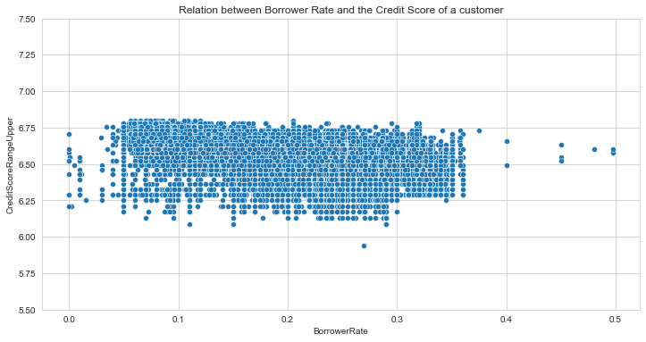

```python
plt.figure(figsize=(12,6))
x_ = loans['BorrowerRate']
y_ = np.log(loans['CreditScoreRangeUpper'])
sns.scatterplot(data = loans, x = x_, y = y_)
plt.ylim([5.5, 7.5]);
plt.title('Relation between Borrower Rate and the Credit Score of a customer');
```

- Initial exploration suggests that no correlation is apparent between a customers credit score and the rate they are charged, but could there be more to it?!

How about the relationship between BorrowerRate and the Loan Term

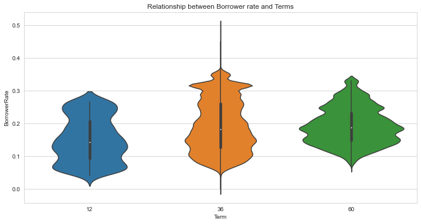

```python
# a violet plot
plt.figure(figsize=(12,6))
sns.violinplot(data = loans, x = loans['Term'], y = loans['BorrowerRate']);
plt.title('Relationship between Borrower rate and Terms');
```

- The most variation in borrowing rate is associated with the 36 months term.
- Borrowing rates variation is approximately uniform across the 12 and 36 months terms.
- However, for the 60 months terms; borrowing rates tend to be distributed with a skew to the left, towards lower rates.

Further, examining the cumaltive distributions of loan term

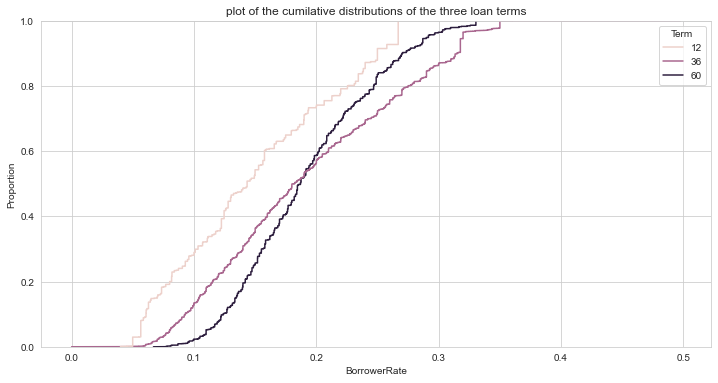

```python
plt.figure(figsize=(12,6))
# a plot of the cumilative distributions of the three loan terms
x_ = loans['BorrowerRate']
y_ = loans['Term']
sns.ecdfplot(data = loans, x = x_, hue = y_, );
plt.title('plot of the cumilative distributions of the three loan terms');
```

- The cdf distribution function indicates that 12 month loans have the lowest borrowing rate.
- Whereas 36 and 60 months have a higher borrowing rate, surprisingly, 36 and 60 months loans have similar borrowing rates on average.

Next, are there any interesting insights on BorrowerRate and Loan Orignial Amount?

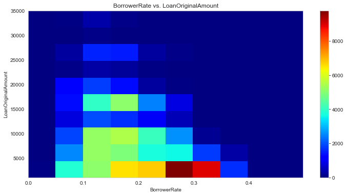

```python
# 2D plot with a color scale representing frequency count
plt.figure(figsize = (12, 6));

x_ = loans['BorrowerRate']
y_ = (loans['LoanOriginalAmount'])

# Construct the plot
plt.hist2d(data = loans, x = x_, y = y_, cmap = plt.cm.jet);
plt.colorbar()
plt.xlabel('BorrowerRate');
plt.ylabel('LoanOriginalAmount');
plt.title('BorrowerRate vs. LoanOriginalAmount');
```

Finally, the rate and Income Range relationship.

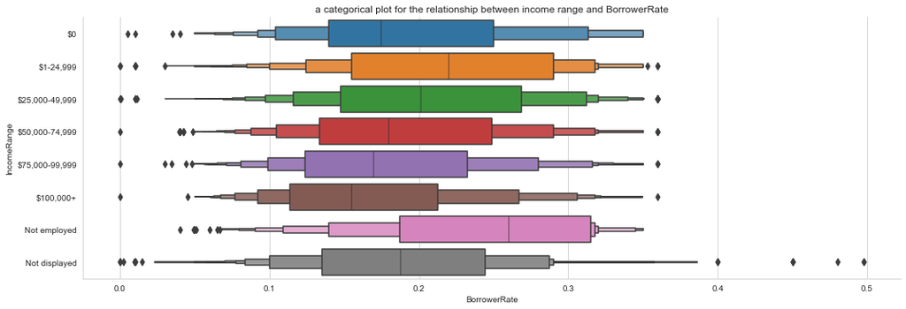

```python
# a categorical plot for the relationship between income range and BorrowerRate
sns.catplot(data = loans, y = 'IncomeRange', x = 'BorrowerRate', kind="boxen", aspect = 3);
plt.title('a categorical plot for the relationship between income range and BorrowerRate');
```

- The average borrower rate tends to fall as the income level is higher for factoring out those with $0 income, the unemployed and those with not displayed income.

## Multivariate Explorations

The aim of this section is to inspect the interactions between Borrower Rate and other variables of interest.

First, observing the relationship between Borrower Rate vs Credit Score vs Loan Original amount

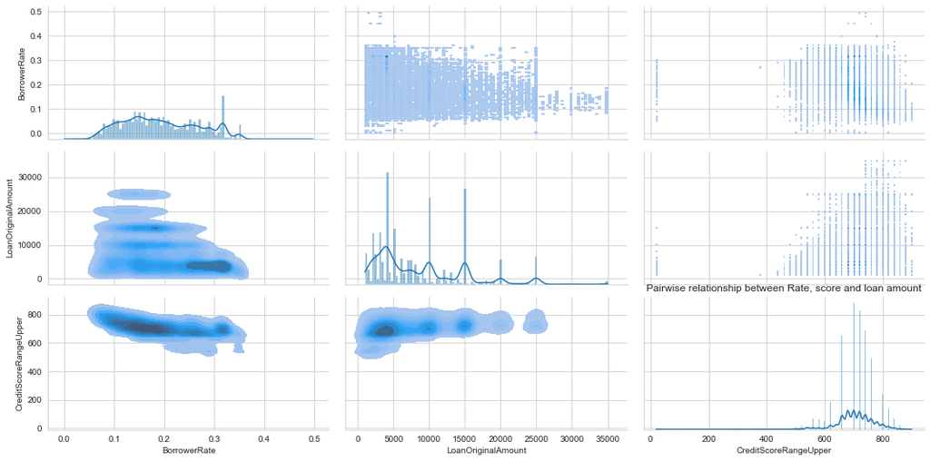

```python
# pairwise relationship between Rate, score and loan amount
vars_ = ['BorrowerRate', 'LoanOriginalAmount', 'CreditScoreRangeUpper']
g = sns.PairGrid(loans[vars_], aspect = 2)
g.map_upper(sns.histplot)
g.map_lower(sns.kdeplot, fill=True)
g.map_diag(sns.histplot, kde=True)
plt.title('Pairwise relationship between Rate, score and loan amount')
```

- No clear correlation is apparent, however it could be seen that as the Loan original amount increases, borrower rates falls.
- Also, as the credit score tend to rise, so does the amount borrowed by the customer.
- However, again no clear effect of credit score or loan original amount can be observed on borrower rate.

Furthermore, cross influence of Credit Score and Term on Borrower Rate.

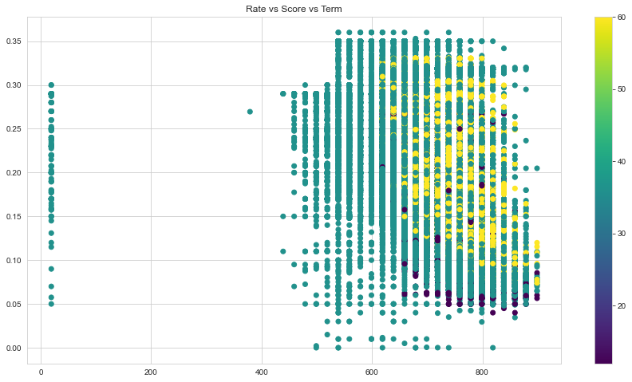

```python
# plot examining the effect of loan term and credit score borrower rate
plt.figure(figsize=(15, 8));
plt.scatter(data = df, x = 'CreditScoreRangeUpper',
            y = 'BorrowerRate', c = 'Term', cmap = plt.cm.viridis);
plt.colorbar();
plt.title('Rate vs Score vs Term');
```

Here, it is clear that a combination of short term, and high credit score (which is usually associated with large loan amount) grants a customer the cheapest borrowing rate. This result does not take into consideration few outliers, whom are obtaining a very low borrowing rate approaching 0.00. Such customers, probably supported by certain government shcemes or recieving employee's discount for example.

Additionally, observing the joint effects of credit score, loan term and adding income range.

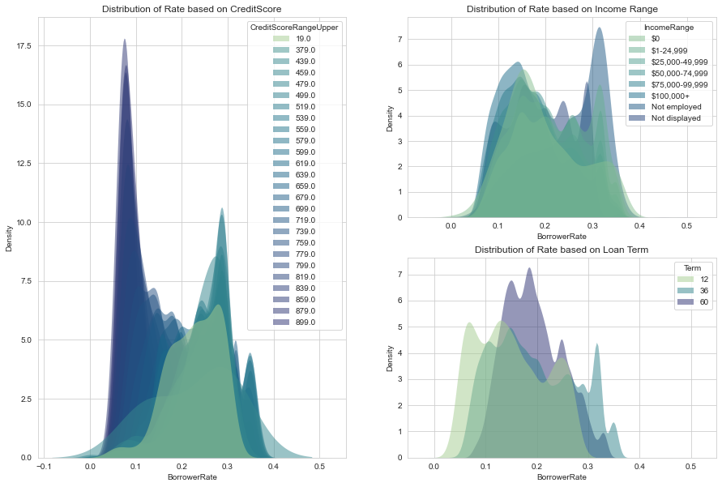

```python
# Construct plots to compare effect of income and loan term
plt.figure(figsize=(15, 10))
plt.subplot(2, 2, 2)
sns.kdeplot(
   data=loans, x="BorrowerRate", hue="IncomeRange",
   fill=True, common_norm=False, palette="crest",
   alpha=.5, linewidth=0);
plt.title('Distribution of Rate based on Income Range');

# Second plot
plt.subplot(2, 2, 4)
sns.kdeplot(
   data=loans, x="BorrowerRate", hue="Term",
   fill=True, common_norm=False, palette="crest",
   alpha=.5, linewidth=0);
plt.title('Distribution of Rate based on Loan Term');

# Third plot
plt.subplot(1, 2, 1)
sns.kdeplot(
   data=loans, x="BorrowerRate", hue="CreditScoreRangeUpper",
   fill=True, common_norm=False, palette="crest",
   alpha=.5, linewidth=0, warn_singular=False);
plt.title('Distribution of Rate based on CreditScore');
```

- Clearly, income range has an effect on the skew of the borrower rate distribution, implying an effect.
- As for the loan term, most effect can be noticed with the 60 months term with a clear centre at approximately 0.17. Followed by the bi-modal distribution of the 36 months term, probably because its the most popular loan term, it has the biggest spread over the borrower rate range.
- A clear disparity in the rate charged can be observed between customers with high credit scores represented by shades of blue, and those with lower credit scores represented by shades of green.
- a negative correlation is observed between credit score and borrower rate.

Next, examine the effect of Income Range and Loan Term on borrower rate.

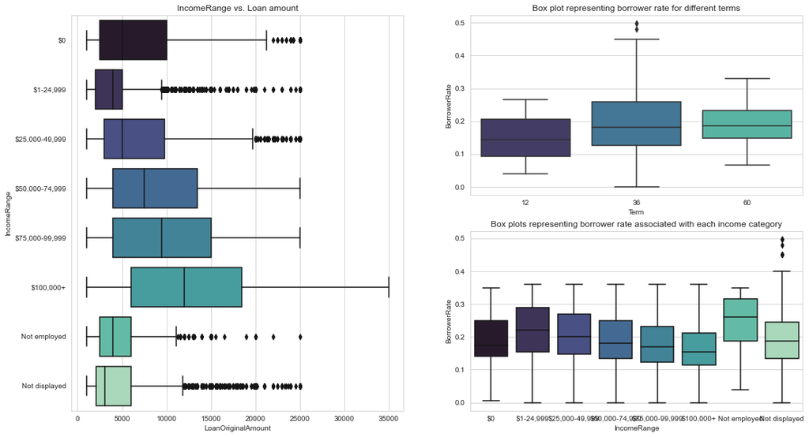

```python
plt.figure(figsize = (18, 10))

plt.subplot(2, 2, 2)
sns.boxplot(x='Term',y='BorrowerRate',data=loans, palette='mako');
plt.title('Box plot representing borrower rate for different terms');

plt.subplot(2, 2, 4)
sns.boxplot(x='IncomeRange',y='BorrowerRate',data=loans, palette='mako');
plt.title('Box plots representing borrower rate associated with each income category');


plt.subplot(1,2,1)
sns.boxplot(x='LoanOriginalAmount', y='IncomeRange', data=loans, palette='mako');
plt.title('IncomeRange vs. Loan amount');
```

Next, it would be interesting to examine the cross influence on borrower rate by loan's term, in addition to, the customer's income range.

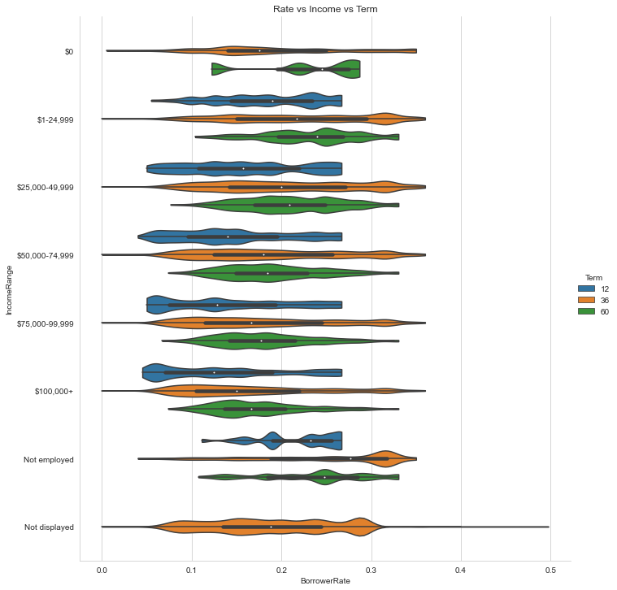

```python
# Rate vs Income vs Term
sns.catplot(x="BorrowerRate", y="IncomeRange", hue="Term",
            kind="violin", bw=.15, cut=0,
            data=loans, aspect = 1, height = 10);
plt.title('Rate vs Income vs Term');
```

- For those with income range of $75,000+ , a short term loan mostly grants them a cheaper borrowing rate than those with lower income levels, and also cheapre rate than those within the same income category but who opted for a longer term loan.
- As for customers with no displayed source of income, it become extremely difficult for loan issuers to assess a fair rate to charge, hence the great disparity.

Another prespective for the interaction between the 3 previous variables, expanding across loan's term

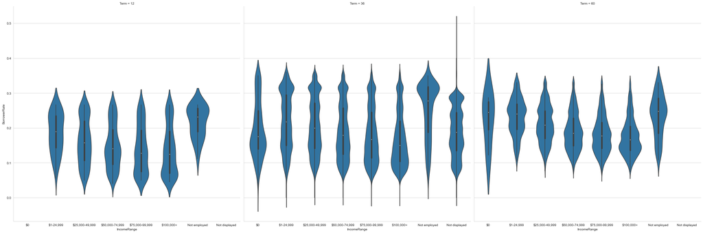

```python
# to ignore warnings
import warnings
warnings.filterwarnings('ignore')

# grid plot of the distribution of credit score vs income range for various terms
g = sns.FacetGrid(data = loans, col = 'Term', height = 10, aspect = 1);
g.map(sns.violinplot,'IncomeRange', 'BorrowerRate');
```

Talk about some of the relationships you observed in this part of the investigation. Were there features that strengthened each other in terms of looking at your feature(s) of interest?

Prosper loan customers come from various backgrounds, with various occupations, income ranges and credit histories. Hence, it becomes a highly complex task for the loan issuer to generate an exact evaluation of the loan amount, rate and terms a customer should be offered. Therefore, prosper loan providers decided that it simplifies the task to assess each customer mainly based on their credit score and the term length of the loan. Income range of the customer also has an effect to be considered. The outliers present in the data also suggest that; borrowing rate is evaluated ad-hoc. This result is inline with the real world, try going online and getting an initial loan quotation, and you will be asked for those variables!

The End. Thank you for your time.

Yours sincerely.

Aaron.

```python
from IPython.display import HTML

HTML('''<script>
code_show=true;
function code_toggle() {
 if (code_show){
 $('div.input').hide();
 } else {
 $('div.input').show();
 }
 code_show = !code_show
}
$( document ).ready(code_toggle);
</script>
The raw code for this IPython notebook is by default hidden for easier reading.
To toggle on/off the raw code, click <a href="javascript:code_toggle()">here</a>.''')
```

The raw code for this IPython notebook is by default hidden for easier reading. To toggle on/off the raw code, click here.